# Building on the SIR Model: A Vector Borne Disease Model for Dengue

Istiaque Ahamed Nabed

26 June 2026

## Introduction

This is my homework for the etivity on vector borne disease modelling. It is based on the Coursera course [Building on the SIR Model](https://www.coursera.org/learn/building-on-the-sir-model/home/welcome) by Imperial College London. In this notebook I build a simple dengue transmission model that includes both the human (host) population and the mosquito (vector) population, then I look at how the mosquito biting rate affects the size of the outbreak. After that I explore two different ways of representing a vector control intervention in the model. The first one changes a parameter over time, and the second one acts instantly on the population at a single point in time.

## Part 1: The Basic Dengue Model

In this model the human population is split into susceptible (Sh), infected (Ih), and recovered (Rh), and the mosquito population is split into susceptible (Sv) and infected (Iv). There is no exposed class here, and the mosquitoes never recover once infected, since dengue stays with them for the rest of their (short) life. I used 10,000 humans and 20,000 mosquitoes, so twice as many vectors as hosts, with a small fraction of each population already infected at the start to kick off the outbreak.

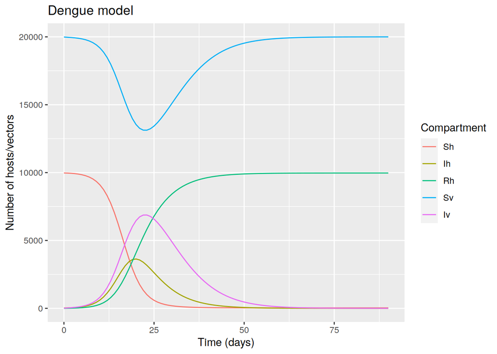

```r
# INPUT
Nh <- 10000  # total number of hosts
Nv <- 20000  # total number of vectors

initial_state_values <- c(Sh = Nh - 0.0028*Nh,
                           Ih = 0.0028*Nh,
                           Rh = 0,
                           Sv = Nv - 0.00057*Nv,
                           Iv = 0.00057*Nv)

parameters <- c(a   = 1,       # mosquito biting rate per day
                 b_v = 0.4,    # probability of infection from an infected host to a susceptible vector
                 b_h = 0.4,    # probability of infection from an infected vector to a susceptible host
                 u_v = 0.25,   # mortality/recruitment rate of the vector
                 r   = 0.167)  # recovery rate from dengue in humans

times <- seq(from = 0, to = 90, by = 1)

# VBD MODEL FUNCTION
vbd_model <- function(time, state, parameters) {

  with(as.list(c(state, parameters)), {

    Nh <- Sh + Ih + Rh   # total human population
    Nv <- Sv + Iv        # total vector population

    # The differential equations
    # Host population dynamics:
    dSh <- -a*b_h*Sh*Iv/Nh
    dIh <- a*b_h*Sh*Iv/Nh - r * Ih
    dRh <- r * Ih
    # Vector population dynamics:
    dSv <- u_v * Nv - a*b_v*Sv*Ih/Nh - u_v * Sv
    dIv <- a*b_v*Sv*Ih/Nh - u_v * Iv

    # Output
    return(list(c(dSh, dIh, dRh, dSv, dIv)))
  })
}

output <- as.data.frame(ode(y = initial_state_values,
                             times = times,
                             func = vbd_model,
                             parms = parameters))

output_long <- melt(as.data.frame(output), id = "time")

ggplot(data = output_long,
       aes(x = time, y = value, colour = variable, group = variable)) +
  geom_line() +
  xlab("Time (days)") +
  ylab("Number of hosts/vectors") +
  labs(colour = "Compartment",
       title = "Dengue model")
```

**My interpretation:** The number of infected humans grows slowly at first, then rises sharply and peaks around day 20 at about 3,600 people infected at the same time. After that the outbreak dies down fairly quickly, dropping to under 100 infected by around day 50 and to almost nothing by day 70. The infected mosquito line follows a similar shape, but interestingly it actually peaks a few days after the human infections do, around day 23. This makes sense once I thought about it, since a mosquito only becomes infected after biting an already infected human, so the vector population lags slightly behind the host population. By day 90 almost the entire human population, just under 10,000 out of 10,000, has ended up in the recovered class, since recovered people in this model stay immune for good and cannot be reinfected.

## Part 2: How Does the Biting Rate Affect the Outbreak?

The biting rate, a, tells us how many bites each mosquito takes per day on average. Since a mosquito has to bite once to get infected and bite again to pass the infection on, I expected this parameter to have a big effect on how fast and how large the outbreak gets. To check this, I reran the model for a range of biting rate values from 0 to 1 per day, keeping every other parameter fixed.

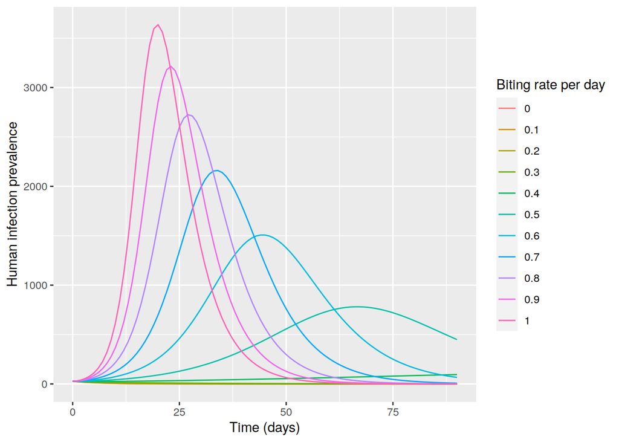

```r
a_values <- seq(0, 1, by = 0.1)                       # a vector of values for the biting rate, ranging from 0 to 1 per day
out_list <- vector(length(a_values), mode = "list")   # create an object (list) to store the output for each value of a

for (i in seq_along(a_values)) {      # for each value in the a_values vector...

  # ... simulate the model and store the output in the out_list object:
  out_list[[i]] <- as.data.frame(ode(y = initial_state_values,
                                      times = times,
                                      func = vbd_model,
                                      parms = c(parameters[c("b_v", "b_h", "u_v", "r")],
                                                a = a_values[i])))
}                                      # close the loop

names(out_list) <- a_values            # rename list elements according to the corresponding biting rate value

# Extract the infected host column from the list and create a dataframe by time
out_inf <- cbind(time = out_list[[1]]$time,
                  sapply(out_list, "[[", "Ih"))

# Turn into long format
out_inf_long <- melt(as.data.frame(out_inf), id = "time")

# Plot the infection prevalence for each biting rate value
ggplot(data = out_inf_long,
       aes(x = time, y = value, colour = variable, group = variable)) +
  geom_line() +
  xlab("Time (days)") +
  ylab("Human infection prevalence") +
  labs(colour = "Biting rate per day")
```

## Part 3: Intervention 1, A Biting Rate That Changes Over Time

This first intervention represents something like the use of bed nets or mosquito repellent that is rolled out partway through the outbreak and later removed. Instead of keeping the biting rate a constant, I made it depend on time inside the model function. From day 0 to 15 the biting rate is left at its normal value of 1 per day, representing the period before the intervention starts. From day 15 to 60 the biting rate drops to 0.25 per day, a 75 percent reduction, representing the intervention being in place. After day 60 the biting rate goes back up to 1 per day, as if the intervention has stopped.

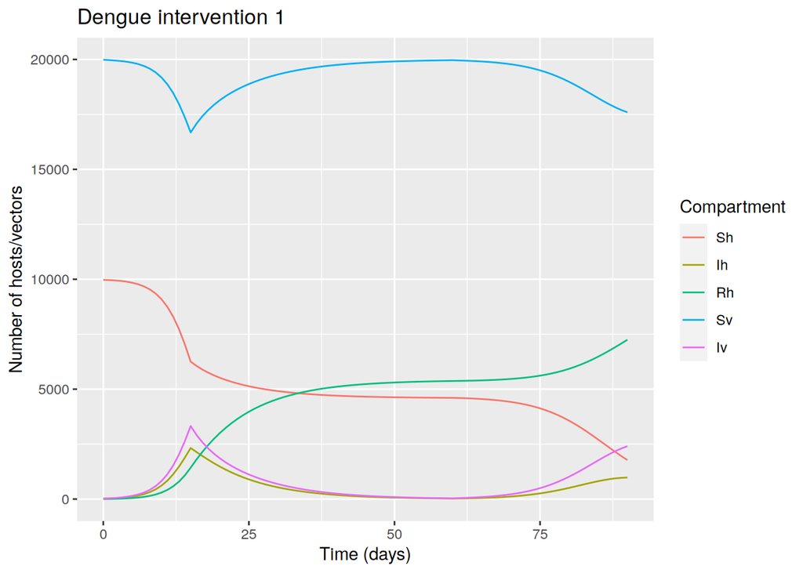

```r
vbd_model_intervention1 <- function(time, state, parameters) {

  with(as.list(c(state, parameters)), {

    Nh <- Sh + Ih + Rh
    Nv <- Sv + Iv

    # a depends on what time it is:
    if (time <= 15){
      a = 1          # before the intervention: normal biting rate
    } else if (time > 15 & time <= 60){
      a = 0.25       # intervention active (day 15-60): biting rate cut by 75%
    } else if (time > 60) {
      a = 1          # intervention stops after day 60: back to normal
    }

    dSh <- -a*b_h*Sh*Iv/Nh
    dIh <- a*b_h*Sh*Iv/Nh - r * Ih
    dRh <- r * Ih
    dSv <- u_v * Nv - a*b_v*Sv*Ih/Nh - u_v * Sv
    dIv <- a*b_v*Sv*Ih/Nh - u_v * Iv

    return(list(c(dSh, dIh, dRh, dSv, dIv)))
  })
}

output1 <- as.data.frame(ode(y = initial_state_values,
                              times = times,
                              func = vbd_model_intervention1,
                              parms = parameters))

output1_long <- melt(as.data.frame(output1), id = "time")

ggplot(data = output1_long,
       aes(x = time, y = value, colour = variable, group = variable)) +
  geom_line() +
  xlab("Time (days)") +
  ylab("Number of hosts/vectors") +
  labs(colour = "Compartment",
       title = "Dengue intervention 1")
```

**My interpretation:** Compared to the model with no intervention, the peak number of infected humans is lower, around 2,300 instead of 3,600, and that peak actually happens right at day 15, the exact moment the intervention kicks in. After that the infected numbers drop fast, down to about 23 people by day 60. But because the biting rate jumps back up to 1 right after day 60, and a large chunk of the population is still susceptible at that point, a second wave starts growing and is still clearly on its way up by day 90, reaching almost 980 infected by the end of the simulation. By day 90 only about 72 percent of the population has been infected so far in this scenario, compared to almost 100 percent without any intervention, but since the second wave had not finished by day 90, this comparison would probably look different if I extended the simulation further. This shows that stopping an intervention while plenty of people are still susceptible can lead to a rebound outbreak, so the timing of when an intervention ends matters just as much as when it starts.

## Part 4: Intervention 2, A One Off Vector Control Event

The second intervention represents something more like a single round of insecticide spraying or fogging, which kills a portion of the mosquito population instantly rather than changing a parameter for a period of time. To model this in deSolve, I used the events argument instead of changing the model function. At day 15, both the susceptible and infected mosquito compartments are multiplied by 0.5, which means half of the mosquito population is removed all at once, regardless of whether they were infected or not. The model function itself is exactly the same as the original one, since the biting rate stays constant the whole time.

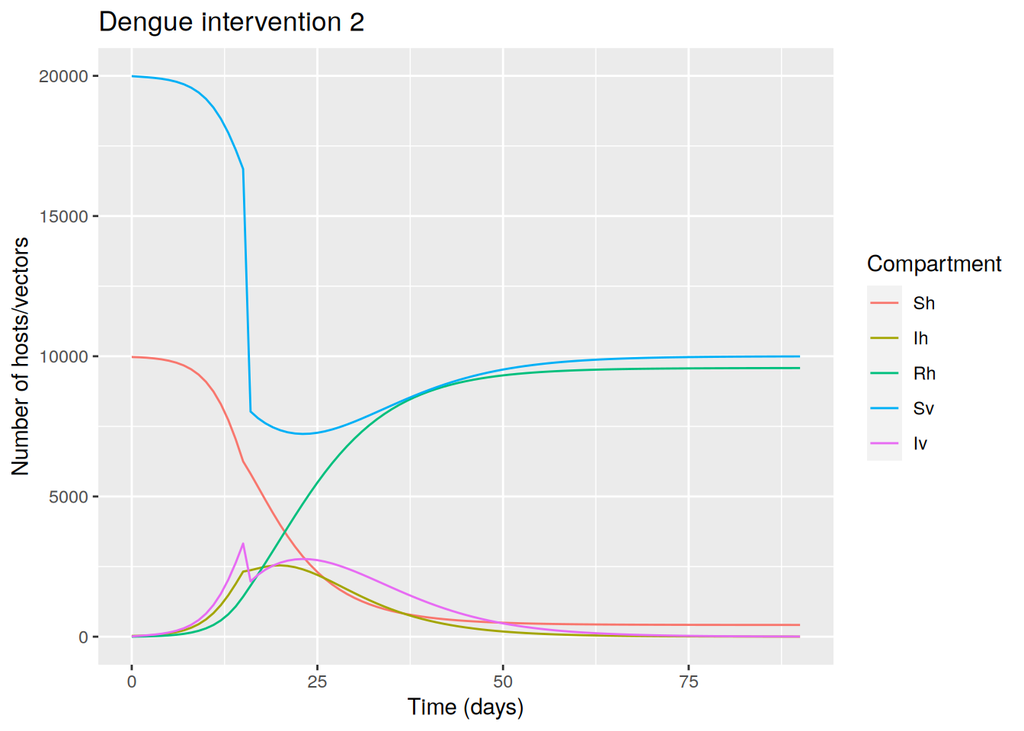

```r
eventdata <- data.frame(var = c("Sv","Iv"), time = c(15,15),
                         value = c(0.5,0.5), method = "multiply")

output2 <- as.data.frame(ode(y = initial_state_values,
                              times = times,
                              func = vbd_model,
                              parms = parameters,
                              events = list(data = eventdata)))

output2_long <- melt(as.data.frame(output2), id = "time")

ggplot(data = output2_long,
       aes(x = time, y = value, colour = variable, group = variable)) +
  geom_line() +
  xlab("Time (days)") +
  ylab("Number of hosts/vectors") +
  labs(colour = "Compartment",
       title = "Dengue intervention 2")
```

## Conclusion

Working through this etivity helped me understand the difference between changing a parameter over time inside the model equations versus using an instant event to change the state variables directly. Both are useful ways to represent real world vector control interventions, but they capture quite different kinds of action. A sustained reduction in the biting rate, like using bed nets or repellent over a period of weeks, kept the cumulative number of infections much lower by day 90 than a single mosquito culling event did. At the same time, Part 3 also showed me that a sustained intervention is not automatically a permanent fix. Once it was switched off at day 60, a second wave started growing again because plenty of susceptible people were still around. So the bigger lesson for me is that both how strong an intervention is and how long it lasts, and what happens to the susceptible population once it stops, all need to be considered together when planning real world dengue control.